# ggstatsplot

ylchen

2021-06-07

- ggstatsplot主要用途：可视化+统计分析
- 在统计学分析方面：目前它支持最常见的统计测试类型：t-test / anova，非参数，相关性分析，列联表分析和回归分析。
- 集中趋势测量方法Central tendency measure Parametric mean 正态分布 Non-parametric median 非正态 Robust trimmed mean 相关性 Bayesian MAP (maximum a posteriori probability) estimate 最大后验估计
- 而在图片输出方面： （1）小提琴图（用于不同组之间连续数据分析）； （2）饼图（用于分类数据的分布检验）； （3）条形图（用于分类数据的分布检验）； （4）散点图（用于两个变量之间的相关性分析）； （5）相关矩阵（用于多个变量之间的相关性分析）； （6）直方图和点图/图表（关于分布的假设检验）； （7）点须图（用于回归模型）。
- 参考：https://indrajeetpatil.github.io/ggstatsplot/index.html

```r
#install.packages("ggstatsplot")
library(ggstatsplot)
```

# 一、ggbetweenstats 多组间的均数比较

- 创建小提琴图、盒子图或两组或条件之间比较的混合图
- 正态异方差（特别是样本数不等的情况下）用Welch’s ANOVA

```r
# for reproducibility
set.seed(123)
head(iris)
```

```
##   Sepal.Length Sepal.Width Petal.Length Petal.Width Species
## 1          5.1         3.5          1.4         0.2  setosa
## 2          4.9         3.0          1.4         0.2  setosa
## 3          4.7         3.2          1.3         0.2  setosa
## 4          4.6         3.1          1.5         0.2  setosa
## 5          5.0         3.6          1.4         0.2  setosa
## 6          5.4         3.9          1.7         0.4  setosa
```

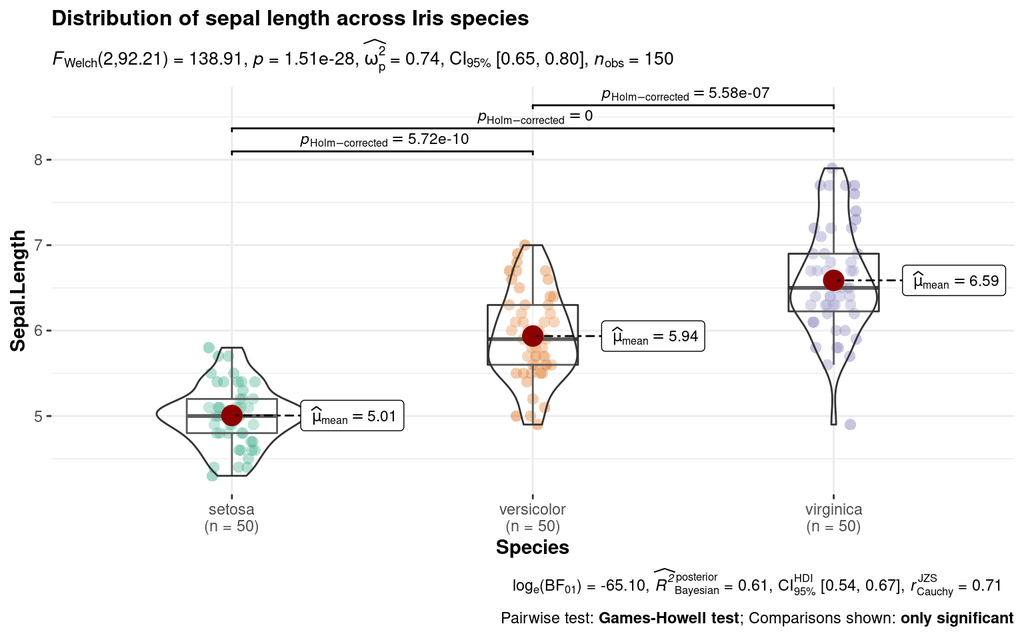

```r
# plot
ggbetweenstats(
  data = iris,
  x = Species,
  y = Sepal.Length,
  title = "Distribution of sepal length across Iris species"
)
```

# 二、ggwithinstats 重复测量设计

- 用法与ggbetweenstats相似，添加了路径连接
- 配对检验

```r
# for reproducibility and data
set.seed(123)
library(WRS2) # for data
library(afex) # to run anova
#BiocManager::install('ggthemes')
head(WineTasting)
```

```
##   Taste   Wine Taster
## 1  5.40 Wine A      1
## 2  5.50 Wine B      1
## 3  5.55 Wine C      1
## 4  5.85 Wine A      2
## 5  5.70 Wine B      2
## 6  5.75 Wine C      2
```

```r
table(WineTasting$Taster) #22对
```

```
##
##  1  2  3  4  5  6  7  8  9 10 11 12 13 14 15 16 17 18 19 20 21 22
##  3  3  3  3  3  3  3  3  3  3  3  3  3  3  3  3  3  3  3  3  3  3
```

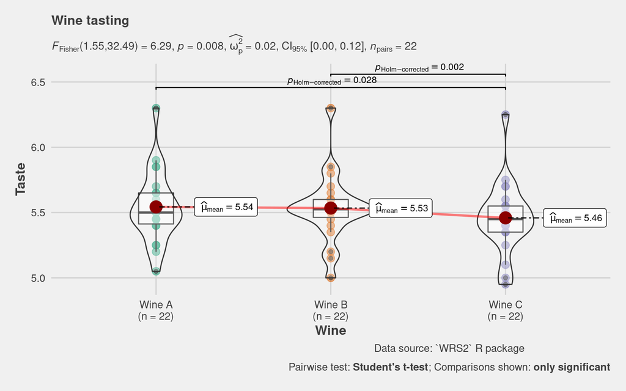

```r
# plot
ggwithinstats(
  data = WineTasting,
  x = Wine,
  y = Taste,
  title = "Wine tasting",
  caption = "Data source: `WRS2` R package",
  ggtheme = ggthemes::theme_fivethirtyeight()
)
```

# 三、gghistostats 直方图

- 观察某连续变量分布情况
- 与固定值test.value进行单样本t检验

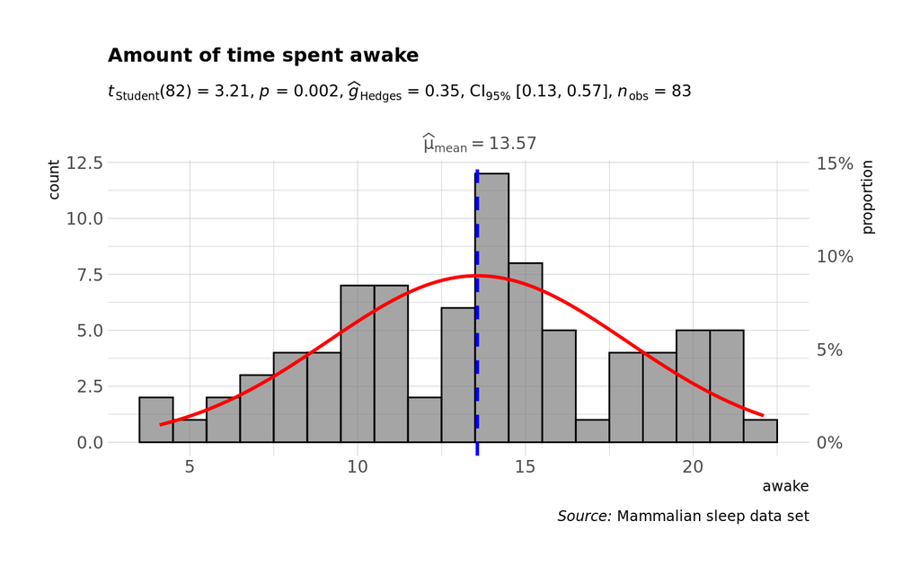

```r
# for reproducibility
set.seed(123)

# plot
gghistostats(
  data = ggplot2::msleep, # dataframe from which variable is to be taken
  x = awake, # numeric variable whose distribution is of interest
  title = "Amount of time spent awake", # title for the plot
  caption = substitute(paste(italic("Source: "), "Mammalian sleep data set")),
  test.value = 12, # default value is 0
  normal.curve = TRUE, # 发布曲线
  normal.curve.args = list(color = "red", size = 1),
  binwidth = 1, # 组距
  ggtheme = hrbrthemes::theme_ipsum_tw(),
  bf.message = FALSE ## 去除贝叶斯相关的统计值
)
```

# 四、ggdotplotstats 点图

- type = “robust” :Bootstrap-t method for one-sample test
- https://zhuanlan.zhihu.com/p/41099219

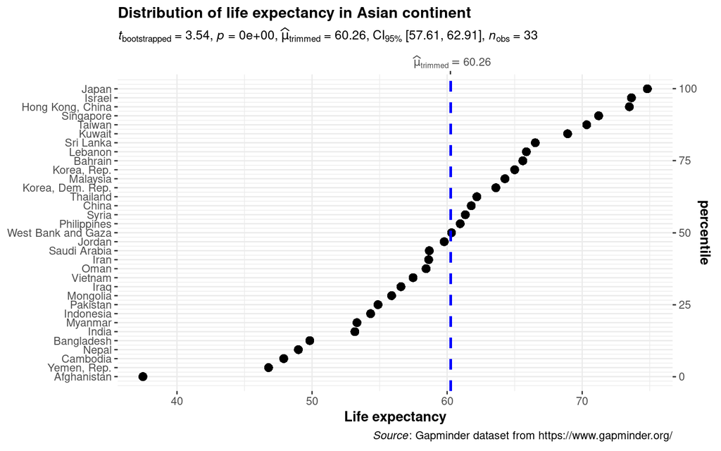

```r
# for reproducibility
set.seed(123)

# plot
ggdotplotstats(
  data = dplyr::filter(.data = gapminder::gapminder, continent == "Asia"),
  y = country,
  x = lifeExp,
  test.value = 55,
  type = "robust",
  title = "Distribution of life expectancy in Asian continent",
  xlab = "Life expectancy",
  caption = substitute(
    paste(
      italic("Source"),
      ": Gapminder dataset from https://www.gapminder.org/"
    )
  )
)
```

# 五、ggscatterstats 散点图

1. 边缘分布类型marginal.type：
- histograms
- boxplots
- density
- violin
- densigram (density + histogram)
2. 假设检验类型type：
- Parametric Pearson’s correlation coefficient
- Non-parametric Spearman’s rank correlation coefficient
- Robust Winsorized Pearson correlation coefficient
- Bayesian Pearson’s correlation coefficient
3. 去除贝叶斯相关的统计值bf.message = FALSE

```r
# for reproducibility
set.seed(123)
data <- dplyr::filter(movies_long, genre == "Action")
head(data)
```

```
## # A tibble: 6 x 8
##   title                             year length budget rating  votes mpaa  genre
##   <chr>                            <int>  <int>  <dbl>  <dbl>  <int> <fct> <fct>
## 1 Lord of the Rings: The Return o…  2003    251     94    9   103631 PG-13 Acti…
## 2 Lord of the Rings: The Fellowsh…  2001    208     93    8.8 157608 PG-13 Acti…
## 3 Lord of the Rings: The Two Towe…  2002    223     94    8.8 114797 PG-13 Acti…
## 4 Star Wars                         1977    125     11    8.8 134640 PG    Acti…
## 5 Star Wars: Episode V - The Empi…  1980    129     18    8.8 103706 PG    Acti…
## 6 Matrix, The                       1999    136     63    8.5 143853 R     Acti…
```

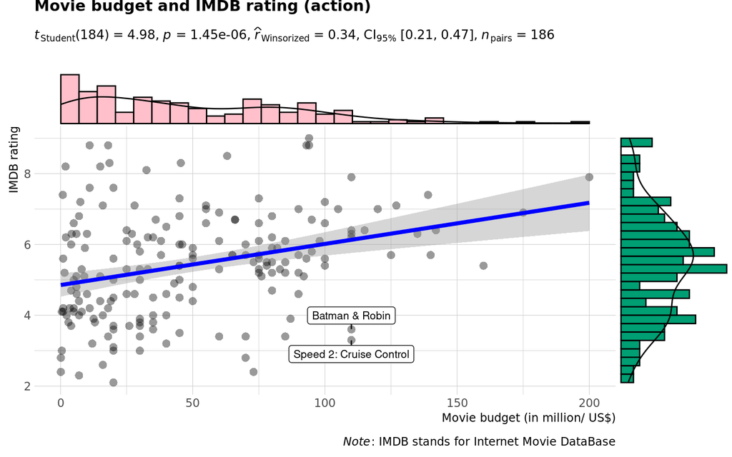

```r
# plot
ggscatterstats(
  data = data,
  x = budget,
  y = rating,
  type = "robust", # Winsorized Pearson correlation coefficient
  xlab = "Movie budget (in million/ US$)", # label for x axis
  ylab = "IMDB rating", # label for y axis
  label.var = title, # 标注点
  label.expression = rating < 5 & budget > 100, # 标注点的条件
  title = "Movie budget and IMDB rating (action)", # title text for the plot
  caption = expression(paste(italic("Note"), ": IMDB stands for Internet Movie DataBase")),#右下方注释
  ggtheme = hrbrthemes::theme_ipsum_ps(), # choosing a different theme
  # turn off `ggstatsplot` theme layer
  marginal.type = "densigram", # 边缘分布
  xfill = "pink", # color fill for x-axis marginal distribution
  yfill = "#009E73" # color fill for y-axis marginal distribution
)
```

# 六、ggcorrmat 相关性图

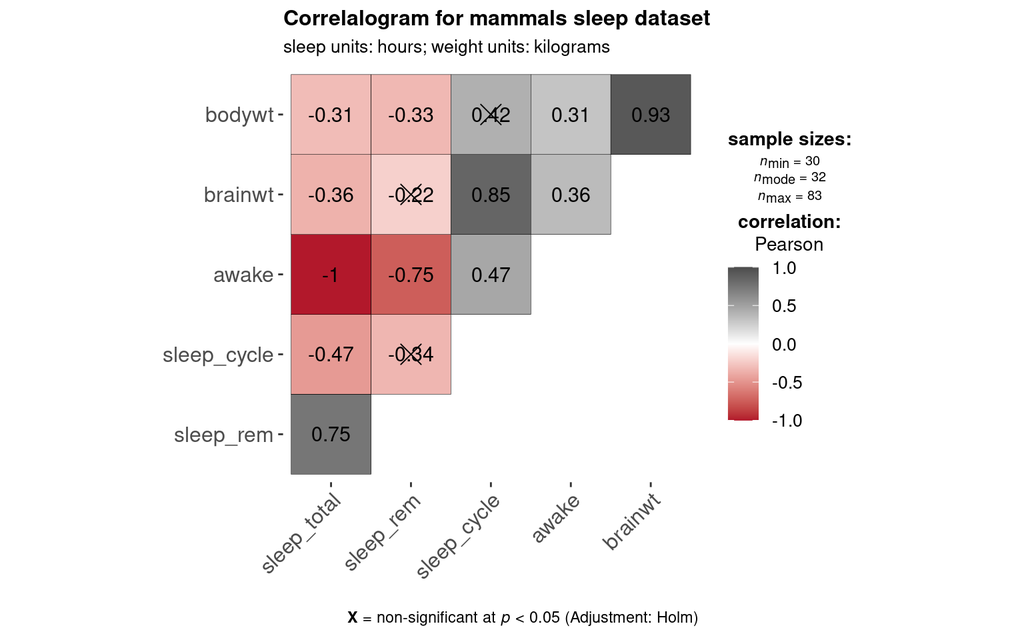

```r
# for reproducibility
set.seed(123)

# as a default this function outputs a correlation matrix plot
ggcorrmat(
  data = ggplot2::msleep,
  type = "Parametric",
  colors = c("#B2182B", "white", "#4D4D4D"),
  title = "Correlalogram for mammals sleep dataset",
  subtitle = "sleep units: hours; weight units: kilograms"
)
```

```r
# output = "dataframe" 具体参数值
head(
  ggcorrmat(
  data = ggplot2::msleep,
  type = "Parametric",
  colors = c("#B2182B", "white", "#4D4D4D"),
  title = "Correlalogram for mammals sleep dataset",
  subtitle = "sleep units: hours; weight units: kilograms",
  output = "dataframe"
))
```

```
## # A tibble: 6 x 11
##   parameter1  parameter2  estimate conf.level conf.low conf.high statistic
##   <chr>       <chr>          <dbl>      <dbl>    <dbl>     <dbl>     <dbl>
## 1 sleep_total sleep_rem      0.752       0.95    0.617    0.844       8.76
## 2 sleep_total sleep_cycle   -0.474       0.95   -0.706   -0.150      -2.95
## 3 sleep_total awake         -1.00        0.95   -1.00    -1.00    -5329.
## 4 sleep_total brainwt       -0.360       0.95   -0.569   -0.108      -2.84
## 5 sleep_total bodywt        -0.312       0.95   -0.494   -0.103      -2.96
## 6 sleep_rem   sleep_cycle   -0.338       0.95   -0.614    0.0120     -1.97
## # … with 4 more variables: df.error <int>, p.value <dbl>, method <chr>,
## #   n.obs <int>
```

# 七、ggpiestats 饼图

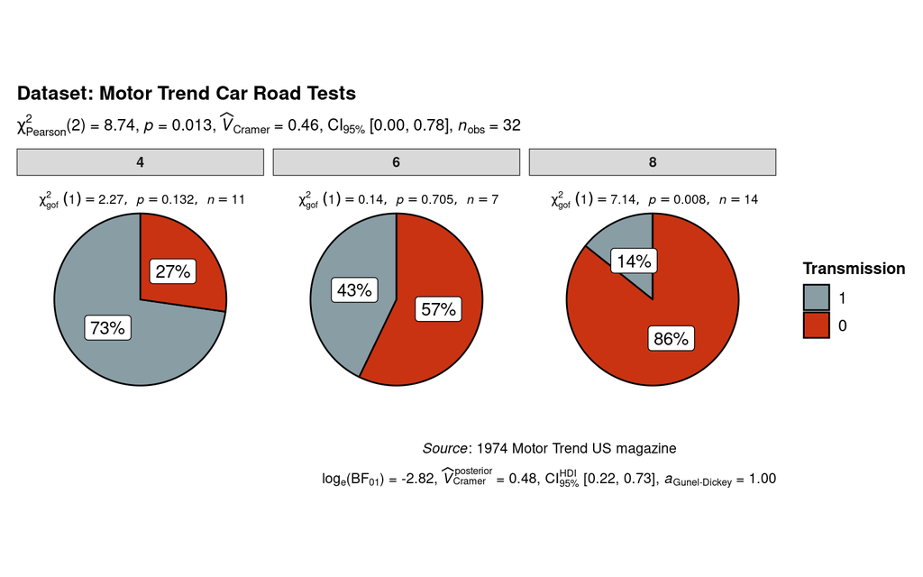

```r
# for reproducibility
set.seed(123)

# plot
ggpiestats(
  data = mtcars,
  x = am,
  y = cyl,
  package = "wesanderson",
  palette = "Royal1", # 调色板
  title = "Dataset: Motor Trend Car Road Tests", # title for the plot
  legend.title = "Transmission", # title for the legend
  caption = substitute(paste(italic("Source"), ": 1974 Motor Trend US magazine"))
)
```

# 八、ggbarstats 柱状图

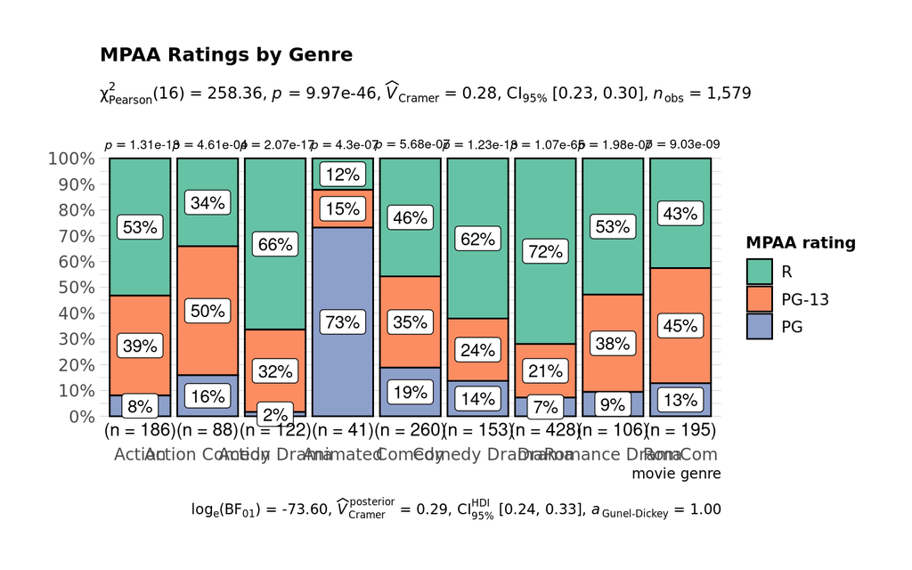

```r
# for reproducibility
set.seed(123)
library(ggplot2)

# plot
ggbarstats(
  data = movies_long,
  x = mpaa,
  y = genre,
  title = "MPAA Ratings by Genre",
  xlab = "movie genre",
  legend.title = "MPAA rating",
  ggtheme = hrbrthemes::theme_ipsum_pub(),
  palette = "Set2"
)
```